# Sequence-2-Sequence forecasting (R)

Daniel S. Hain (dsh@business.aau.dk)

Updated December 04, 2020

```r
library(tidyverse)
library(magrittr)
library(keras)
library(tidymodels) # Or only load the 'rsample' and recipes on its own
```

# Workshop Stock prediction

Task:

1. Get some stock data (tip: Use tidyquant)
   - Limit yourself for now to on e stock
   - Limit yourself to one variable (preferably some price data)
2. Develop a one-step ahead prediction of prices (or their movements)

# Load some data

## Select a stock abnd load the data

- We will use the tidyquant package to download stock data

```r
library(tidyquant) # My favorite package to get stock data
```

```r
tickers = c("AAPL") # Just for fun, we get a couple of stocks

data_stocks <- tq_get(tickers,
               from = "2000-01-01",
               to = "2020-11-30",
               get = "stock.prices" # What we want to get.... here prices
               )
```

## Some plots for exploration…

```r
data_stocks %>% glimpse()
```

```
Rows: 5,261
Columns: 8
$ symbol   <chr> "AAPL", "AAPL", "AAPL", "AAPL", "AAPL", "AAPL", "AAPL", "AAPL", "AAPL", "AAPL", "AAPL", "AAPL", "AAPL", "AAPL", "AAPL", "AAPL", "AAPL", "AAPL", "AAPL", "AAPL", "AAPL", "A…
$ date     <date> 2000-01-03, 2000-01-04, 2000-01-05, 2000-01-06, 2000-01-07, 2000-01-10, 2000-01-11, 2000-01-12, 2000-01-13, 2000-01-14, 2000-01-18, 2000-01-19, 2000-01-20, 2000-01-21, 2…
$ open     <dbl> 0.936384, 0.966518, 0.926339, 0.947545, 0.861607, 0.910714, 0.856585, 0.848214, 0.843610, 0.892857, 0.901786, 0.943080, 1.031250, 1.020089, 0.968192, 0.937500, 0.982143, …
$ high     <dbl> 1.004464, 0.987723, 0.987165, 0.955357, 0.901786, 0.912946, 0.887277, 0.852679, 0.881696, 0.912946, 0.946429, 0.970982, 1.084821, 1.020089, 1.006696, 1.010045, 1.019531, …
$ low      <dbl> 0.907924, 0.903460, 0.919643, 0.848214, 0.852679, 0.845982, 0.808036, 0.772321, 0.825893, 0.887277, 0.896763, 0.922991, 1.013393, 0.983817, 0.938616, 0.914063, 0.979911, …
$ close    <dbl> 0.999442, 0.915179, 0.928571, 0.848214, 0.888393, 0.872768, 0.828125, 0.778460, 0.863839, 0.896763, 0.928013, 0.951451, 1.013393, 0.993862, 0.948661, 1.002232, 0.983817, …
$ volume   <dbl> 535796800, 512377600, 778321600, 767972800, 460734400, 505064000, 441548800, 976068800, 1032684800, 390376000, 459177600, 597643200, 1831132800, 495924800, 440876800, 497…
$ adjusted <dbl> 0.855168, 0.783068, 0.794528, 0.725771, 0.760149, 0.746780, 0.708581, 0.666086, 0.739140, 0.767311, 0.794050, 0.814104, 0.867105, 0.850393, 0.811717, 0.857555, 0.841798, …
```

```r
data_stocks %>% head()
```

| symbol | date | open | high | low | close | volume | adjusted |
| --- | --- | --- | --- | --- | --- | --- | --- |
| AAPL | 2000-01-03 | 0.936384 | 1.004464 | 0.907924 | 0.999442 | 535796800 | 0.855168 |
| AAPL | 2000-01-04 | 0.966518 | 0.987723 | 0.903460 | 0.915179 | 512377600 | 0.783068 |
| AAPL | 2000-01-05 | 0.926339 | 0.987165 | 0.919643 | 0.928571 | 778321600 | 0.794528 |
| AAPL | 2000-01-06 | 0.947545 | 0.955357 | 0.848214 | 0.848214 | 767972800 | 0.725771 |
| AAPL | 2000-01-07 | 0.861607 | 0.901786 | 0.852679 | 0.888393 | 460734400 | 0.760149 |
| AAPL | 2000-01-10 | 0.910714 | 0.912946 | 0.845982 | 0.872768 | 505064000 | 0.746780 |

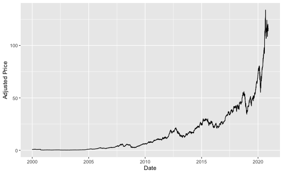

```r
data_stocks %>%
  ggplot(aes(x = date, y = adjusted,)) +
  geom_line() +
  labs(x = 'Date', y = "Adjusted Price")
```

# Preprocessing

## Limit data

```r
data <- data_stocks %>%
  rename(index = date, value = adjusted) %>%
  select(index, value) %>%
  arrange(index) %>%
  drop_na()
```

## Remodel value as percentage change

- It is always easier to model change rather than absolute prices, so we create a variable measuring the percentage change of price instead

```r
data %<>%
  mutate(value = (value - lag(value,1)) / lag(value,1) ) %>%
  drop_na()
```

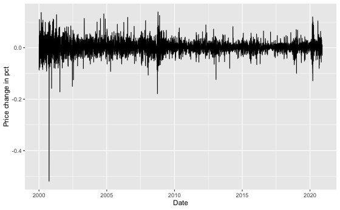

```r
data %>%
  ggplot(aes(x = index, y = value)) +
  geom_line() +
  labs(x = 'Date', y = "Price change in pct")
```

## Train & Test split

- We do a time-series split which keeps the sequencing of the data

```r
# We use time_splits here to maintain the sequences
data_split <- data %>% initial_time_split(prop = 0.75)
```

[output not shown]

[output cut: 990 more lines]

- Lets see from where till when the train/test samples are

```r
# See ehat we got
data_train %>% pull(index) %>% min()
```

```
[1] "2000-01-04"
```

```r
data_train %>% pull(index) %>% max()
```

```
[1] "2015-09-09"
```

```r
data_test %>% pull(index) %>% min()
```

```
[1] "2015-09-10"
```

```r
data_test %>% pull(index) %>% max()
```

```
[1] "2020-11-27"
```

## Define a reciepe

- We only apply min-max scaling herewith `step_range`

```r
data_recipe <- data_train %>%
  recipe(value ~ .) %>%
  step_range(value, min = -1, max = 1)  %>%
  step_arrange(index) %>%
  prep()
```

- We save the min and max to rescale later again

```r
# Preserve the values for later (to reconstruct original values)
prep_history <- tibble(
  min = data_recipe$steps[[1]]$ranges[1],
  max = data_recipe$steps[[1]]$ranges[2]
)
```

```r
prep_history
```

| min | max |
| --- | --- |
| -0.5186917 | 0.1390496 |

## Get processedv train & test data

```r
# Number of lags
n_lag = 1
```

- We now create a x and y split. Since we here always predict the next observation, that’s easy. We will just set y= lead(x, 1)
- We treplace the last missing observation with the lagged value

```r
# TRain data
x_train <- data_recipe %>% juice()

y_train <- data_recipe %>%  juice() %>%
  mutate(value = value %>% lead(1)) %>%
  mutate(value = ifelse(is.na(value), lag(value, 1), value))

# And the same for the test data
x_test <- data_recipe %>% bake(data_test)

y_test <- data_recipe %>%  bake(data_test) %>%
  mutate(value = value %>% lead(1)) %>%
  mutate(value = ifelse(is.na(value), lag(value, 1), value))
```

## Transform to a 3d tensor for keras

```r
# TRansforming the x sequence to a 3d tensor (necessary for LSTMs)
x_train_arr <- x_train %>% pull(value) %>% as.numeric() %>% array_reshape(dim = c(length(.), 1, 1))
x_test_arr <- x_test %>% pull(value) %>% as.numeric() %>% array_reshape(dim = c(length(.), 1, 1))

y_train_arr <- y_train %>% pull(value) %>% as.numeric() %>% array_reshape(dim = c(length(.), 1))
y_test_arr <- y_test %>% pull(value) %>% as.numeric() %>% array_reshape(dim = c(length(.), 1))
```

# LSTM

## Define model

```r
model <- keras_model_sequential() %>%
  # # First LSTM Layer
  layer_lstm(units            = 64,
             input_shape= c(1, 1), #  timesteps, features
             return_sequences = TRUE,
             ) %>%
  # Second LSTM Layer
  layer_lstm(units            = 64,
             dropout            = 0.1,
             recurrent_dropout= 0.1,
             #stateful         = TRUE,
             return_sequences = FALSE) %>%
  # A dropout layer
  layer_dropout(rate = 0.1) %>%
  # A DENSE LAYER IN BETWEEN
  layer_dense(units = 32, activation = 'relu') %>%
  #Final prediction layer
  layer_dense(units = 1, activation = 'linear')


# Compile model
model %>%
  compile(loss = "mse",
          metric = 'mse',
          optimizer = "adam")
```

```r
model %>% summary()
```

```
Model: "sequential_1"
______________________________________________________________________________________________________________________________________________________________________________________________
Layer (type)                                                                         Output Shape                                                                Param #
==============================================================================================================================================================================================
lstm_3 (LSTM)                                                                        (None, 1, 64)                                                               16896
______________________________________________________________________________________________________________________________________________________________________________________________
lstm_2 (LSTM)                                                                        (None, 64)                                                                  33024
______________________________________________________________________________________________________________________________________________________________________________________________
dropout_1 (Dropout)                                                                  (None, 64)                                                                  0
______________________________________________________________________________________________________________________________________________________________________________________________
dense_3 (Dense)                                                                      (None, 32)                                                                  2080
______________________________________________________________________________________________________________________________________________________________________________________________
dense_2 (Dense)                                                                      (None, 1)                                                                   33
==============================================================================================================================================================================================
Total params: 52,033
Trainable params: 52,033
Non-trainable params: 0
______________________________________________________________________________________________________________________________________________________________________________________________
```

## Fitting the model

```r
hist_model <- model %>% fit(x          = x_train_arr,
                            y          = y_train_arr,
                            epochs     = 10,
                            verbose    = 1,
                            batch_size = 64,
                            validation_split = 0.25,
                            shuffle    = FALSE)
```

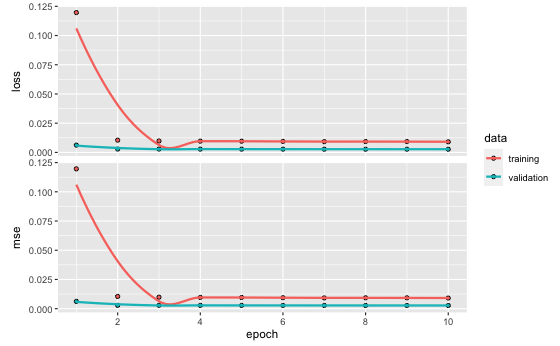

```r
hist_model %>% plot()
```

```r
model %>% evaluate(x_test_arr, y_test_arr)
```

```
       loss         mse
0.003453283 0.003453283
```

## Predicting Stock changes

- We first predict the output of our test data

```r
model_pred <- model %>% predict(x_test_arr)
```

```r
reverse_minmax <- function(x, min, max) {
  x_re <- (x*(max - min)) + min
  }
```

- We apply it with our data and the saved min and max values from the recipe

```r
model_pred_rescaled <- model_pred %>% reverse_minmax(min = prep_history$min, max = prep_history$max)
```

Plot the results:

```r
eval <- tibble(
  index = data_test %>% pull(index),
  truth = data_test %>% pull(value),
  pred = model_pred_rescaled
)
```

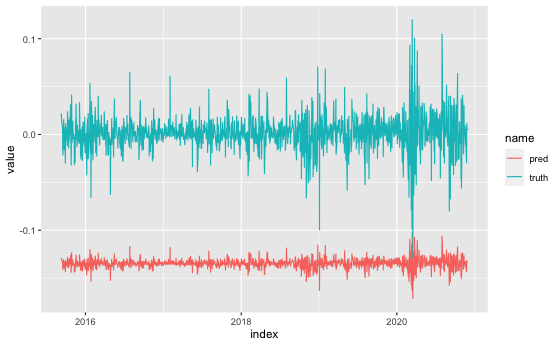

```r
eval %>%
  pivot_longer(-index) %>%
  ggplot(aes(x = index, y = value, col = name)) +
  geom_line()
```

```r
tsteps_x = 5
tsteps_y = 5
```

```r
train_arr <- x_train %>% pull(value) %>% as.numeric() %>% matrix(ncol = (tsteps_x + tsteps_y))
```

```r
x_train_arr <- train_arr[,1:tsteps_x] %>% array_reshape(dim = c(length(.), 1, 1))
```

```r
#x_train %<>% pull(value) %>% as.numeric() %>% array_reshape(dim = c(length(.), 1, 1))
#x_test %<>% pull(value) %>% as.numeric() %>% array_reshape(dim = c(length(.), 1, 1))

#y_train %<>% pull(value) %>% as.numeric() %>% array_reshape(dim = c(length(.), 1))
#y_test %<>% pull(value) %>% as.numeric() %>% array_reshape(dim = c(length(.), 1))
```